# Intro to R Time Series (and a few Finance Packages)

### 2.2 `ts`-aware base R functions

We can process and analyze `ts` objects just by using base R functions. Let’s try a few of them.

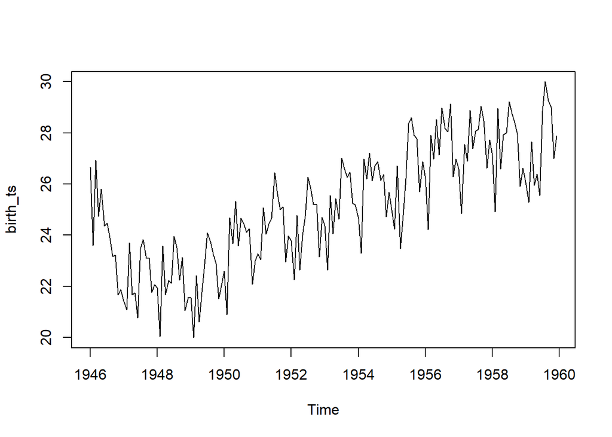

```r
# plot the time series
plot(birth_ts)
```

`plot()` is a generic function that plots different graphs depending on its input. The `plot()` here actually invokes `plot.ts()`, the plotting method for `ts` objects.

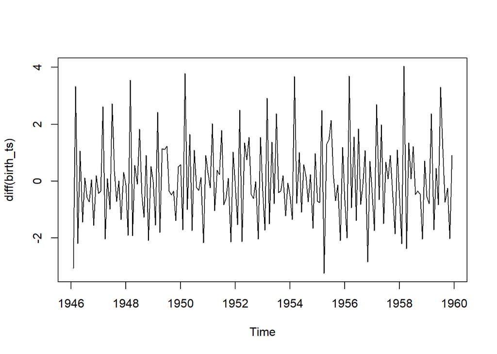

```r
# plot the first difference of birth_ts
plot.ts(diff(birth_ts))
```

```r
# time() create a vector of time from the time series
time(birth_ts)
```

```
##           Jan      Feb      Mar      Apr      May      Jun      Jul
## 1946 1946.000 1946.083 1946.167 1946.250 1946.333 1946.417 1946.500
## 1947 1947.000 1947.083 1947.167 1947.250 1947.333 1947.417 1947.500
## 1948 1948.000 1948.083 1948.167 1948.250 1948.333 1948.417 1948.500
## 1949 1949.000 1949.083 1949.167 1949.250 1949.333 1949.417 1949.500
## 1950 1950.000 1950.083 1950.167 1950.250 1950.333 1950.417 1950.500
## 1951 1951.000 1951.083 1951.167 1951.250 1951.333 1951.417 1951.500
## 1952 1952.000 1952.083 1952.167 1952.250 1952.333 1952.417 1952.500
## 1953 1953.000 1953.083 1953.167 1953.250 1953.333 1953.417 1953.500
## 1954 1954.000 1954.083 1954.167 1954.250 1954.333 1954.417 1954.500
## 1955 1955.000 1955.083 1955.167 1955.250 1955.333 1955.417 1955.500
## 1956 1956.000 1956.083 1956.167 1956.250 1956.333 1956.417 1956.500
## 1957 1957.000 1957.083 1957.167 1957.250 1957.333 1957.417 1957.500
## 1958 1958.000 1958.083 1958.167 1958.250 1958.333 1958.417 1958.500
## 1959 1959.000 1959.083 1959.167 1959.250 1959.333 1959.417 1959.500
##           Aug      Sep      Oct      Nov      Dec
## 1946 1946.583 1946.667 1946.750 1946.833 1946.917
## 1947 1947.583 1947.667 1947.750 1947.833 1947.917
## 1948 1948.583 1948.667 1948.750 1948.833 1948.917
## 1949 1949.583 1949.667 1949.750 1949.833 1949.917
## 1950 1950.583 1950.667 1950.750 1950.833 1950.917
## 1951 1951.583 1951.667 1951.750 1951.833 1951.917
## 1952 1952.583 1952.667 1952.750 1952.833 1952.917
## 1953 1953.583 1953.667 1953.750 1953.833 1953.917
## 1954 1954.583 1954.667 1954.750 1954.833 1954.917
## 1955 1955.583 1955.667 1955.750 1955.833 1955.917
## 1956 1956.583 1956.667 1956.750 1956.833 1956.917
## 1957 1957.583 1957.667 1957.750 1957.833 1957.917
## 1958 1958.583 1958.667 1958.750 1958.833 1958.917
## 1959 1959.583 1959.667 1959.750 1959.833 1959.917
```

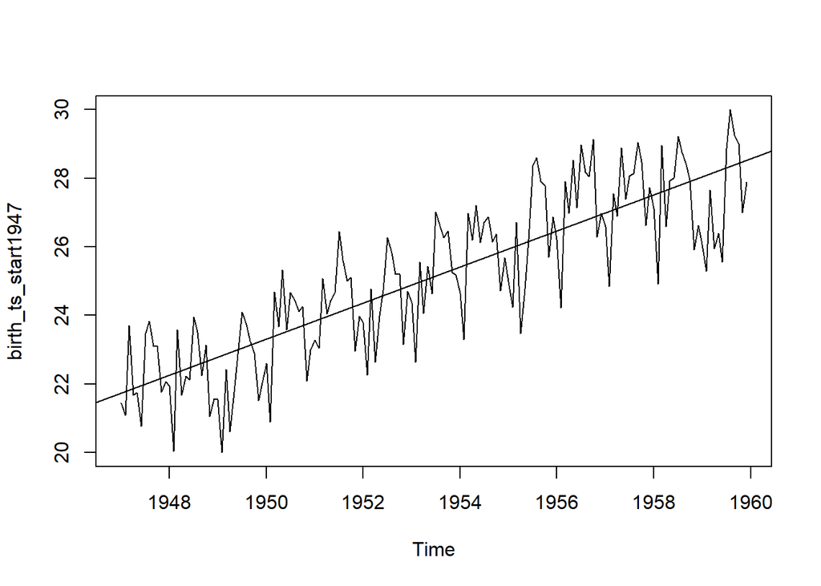

```r
# subset the series to make it start from 1947 (this is just to show you how to slice a ts)
# plot the new series and add a regression line (y is birth_ts_start1947 and x is time)
birth_ts_start1947 <- window(birth_ts, start = 1947)
plot(birth_ts_start1947)
abline(reg = lm(birth_ts_start1947 ~ time(birth_ts_start1947)))
```

```r
# print out the cycle of the time series
cycle(birth_ts)
```

```
##      Jan Feb Mar Apr May Jun Jul Aug Sep Oct Nov Dec
## 1946   1   2   3   4   5   6   7   8   9  10  11  12
## 1947   1   2   3   4   5   6   7   8   9  10  11  12
## 1948   1   2   3   4   5   6   7   8   9  10  11  12
## 1949   1   2   3   4   5   6   7   8   9  10  11  12
## 1950   1   2   3   4   5   6   7   8   9  10  11  12
## 1951   1   2   3   4   5   6   7   8   9  10  11  12
## 1952   1   2   3   4   5   6   7   8   9  10  11  12
## 1953   1   2   3   4   5   6   7   8   9  10  11  12
## 1954   1   2   3   4   5   6   7   8   9  10  11  12
## 1955   1   2   3   4   5   6   7   8   9  10  11  12
## 1956   1   2   3   4   5   6   7   8   9  10  11  12
## 1957   1   2   3   4   5   6   7   8   9  10  11  12
## 1958   1   2   3   4   5   6   7   8   9  10  11  12
## 1959   1   2   3   4   5   6   7   8   9  10  11  12
```

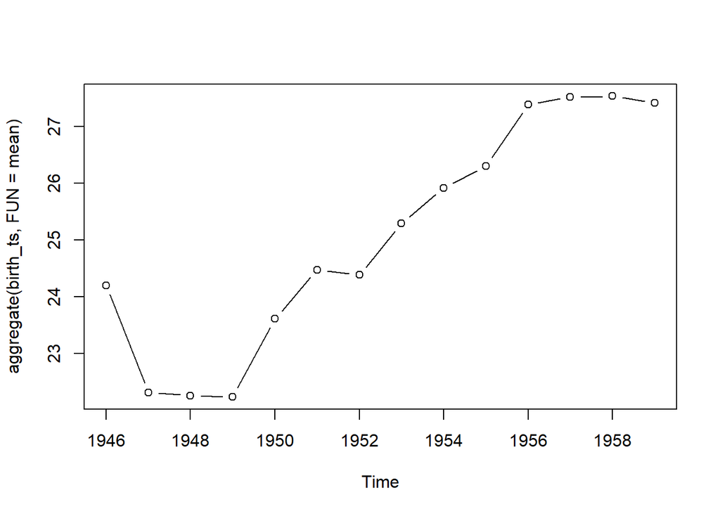

```r
# find mean number of births by year and display the year on year trend
# type = "b" mean plot both point and line
plot(aggregate(birth_ts, FUN = mean), type = "b")
```

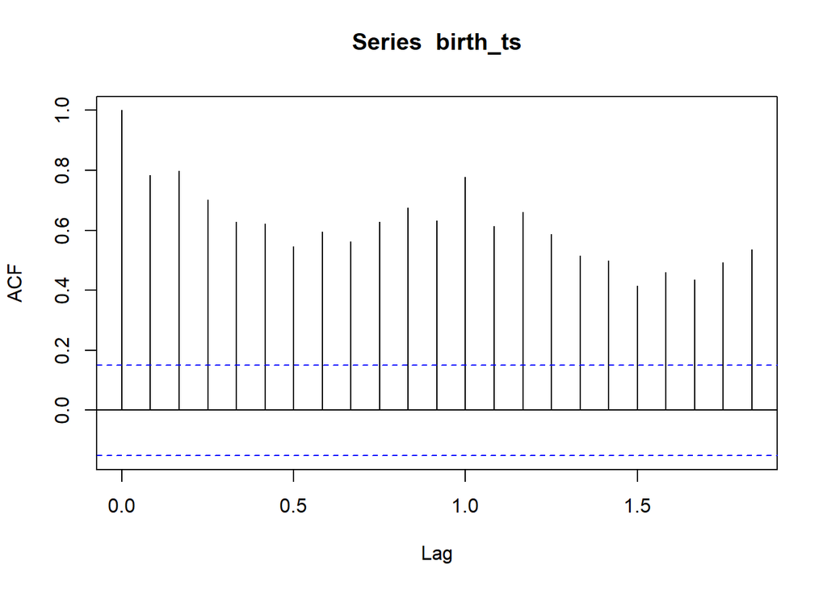

```r
# acf of the series
acf(birth_ts)
```

ACF - Autocorrelation Function. ACF calculates the correlation of a time series with its own lagged values. (see [here](https://nwfsc-timeseries.github.io/atsa-labs/sec-ts-correlation-within-and-among-time-series.html#sec-ts-autocorrelation-function-acf))

The above plot starts with lag 0, and then lag 1, 2 and so on. The x-axis is in year unit, i.e., 1 is 12th/1-year lag.

The ACF of our birth time series decreases slowly because it is not stationary. (It has an obvious upward trend and seasonality.)

You can plot PACF easily using pacf() function.

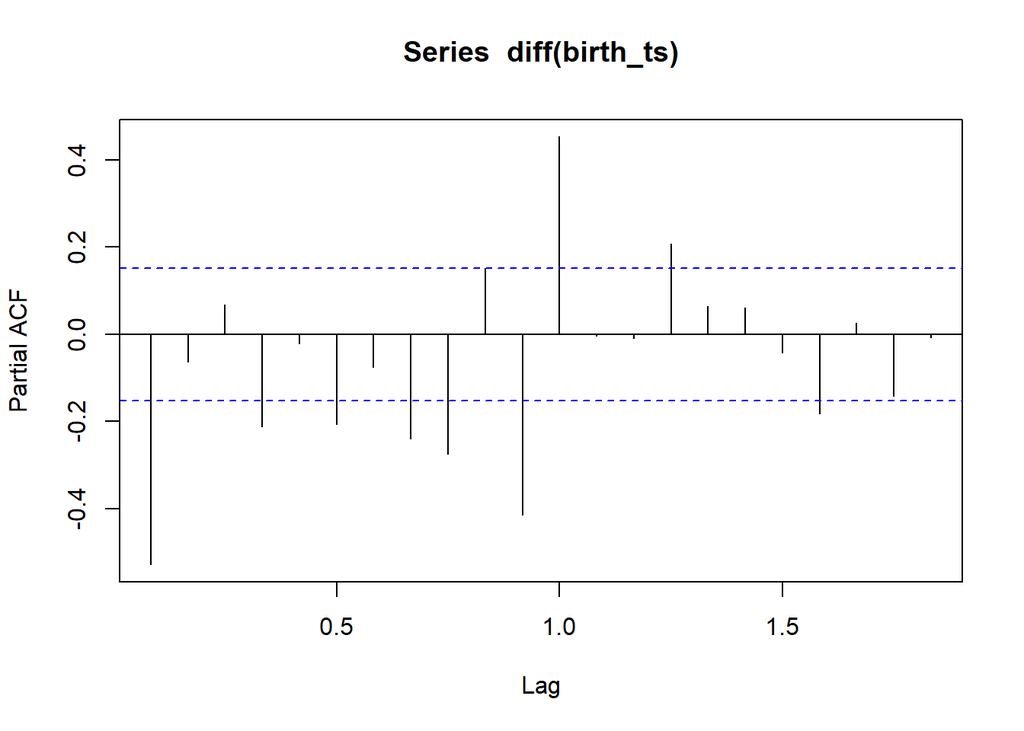

```r
# pacf on the series
pacf(diff(birth_ts))
```

PACF - Partial ACF. PACF “gives the partial correlation of a time series with its own lagged values, controlling for the values of the time series at all shorter lags.” ([wiki](https://en.wikipedia.org/wiki/Partial_autocorrelation_function).

The above plot starts with lag 1, and then lag 2, 3 and so on. The x-axis is in year unit, i.e., 1 is 12th/1-year lag.

ACF and PACF help identify parameters for time series models, e.g., p, i, q in AR(p), MA(q), or ARIMA(p, i, q) model.

### 2.3. the `forecast` package

From the early time-series plot, we see the series has

1. an upward year-by-year trend
2. a seasonal component with cycle of 1 year
3. a relatively stable variance over time

Let’s fit the series with a seasonal ARIMA model `arima(p, i, q)(P, I, Q)[S]`. Instead of manually identify the model parameters (through ACF and PACF graphs) and fit the model using base R functions, we will use the `auto.arima()` function from the `forcast` package.

```r
library(forecast)
# fit a seasonal ARIMA model arima(p, i, q)(P, I, Q)[S]
fit <- auto.arima(birth_ts, approximation = FALSE)
fit
```

```
## Series: birth_ts
## ARIMA(3,1,0)(2,1,1)[12]
##
## Coefficients:
##           ar1      ar2      ar3     sar1     sar2     sma1
##       -0.0784  -0.2068  -0.1828  -0.4316  -0.2916  -0.6614
## s.e.   0.0815   0.0800   0.0820   0.1186   0.1096   0.1170
##
## sigma^2 estimated as 0.3971:  log likelihood=-154.75
## AIC=323.51   AICc=324.27   BIC=344.81
```

Predict based on the fitted model.

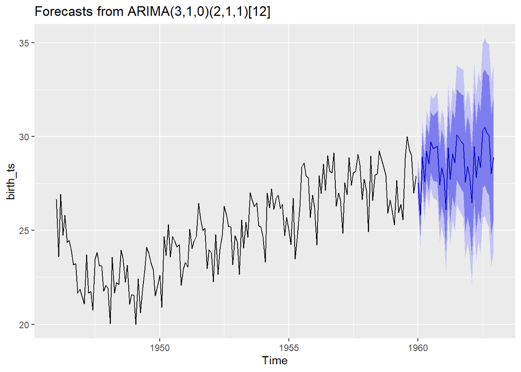

```r
# predict 36 months ahead
pred <- forecast(fit, h = 36)
autoplot(pred)
```

We can chain the process using pipe operator (`%>%`) as well.

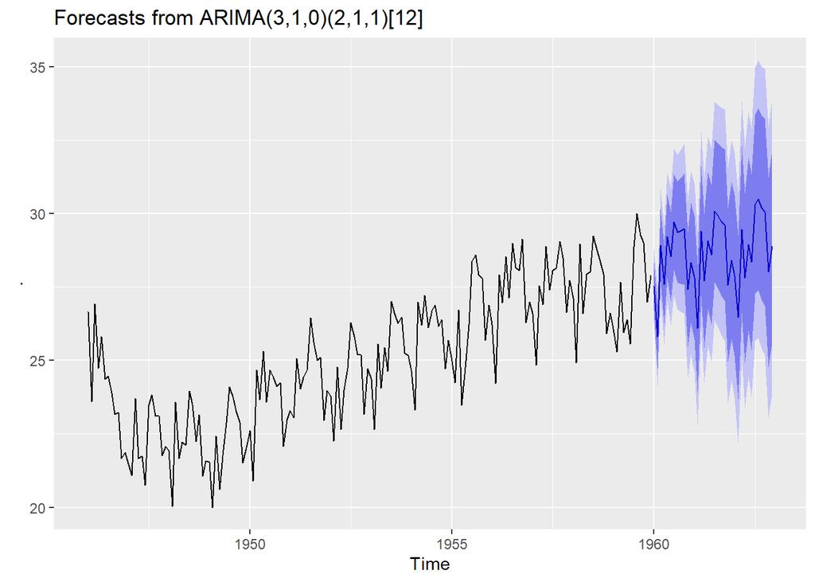

```r
birth_ts %>%
  auto.arima(approximation = FALSE) %>%
  forecast(h = 36) %>%
  autoplot()
```

Decomposing and visualizing trend, seasonality, and remaining errors can be done easily using base R `decompose()` and forecast package’s `autoplot()`.

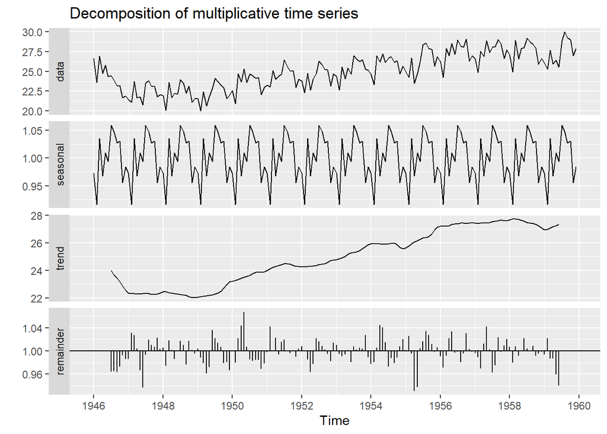

```r
birth_ts %>%
  decompose(type="multiplicative") %>%
  autoplot()
```

You certainly should read `forecast` package document to understand the theory behind `auto.arima()` and `decompose()`.

1. forecast package [website](http://pkg.robjhyndman.com/forecast/)
2. [Automatic Time Series Forcasting: the forecast Package for R](https://cran.r-project.org/web/packages/forecast/vignettes/JSS2008.pdf)
3. [Classical decomposition](https://otexts.com/fpp2/classical-decomposition.html) chapter in the book [Forecasting: Principles and Practice](https://otexts.com/fpp2/).

Forecast package has many more useful functions (e.g. better ACF and PACF plots), I’ll leave you to explore them on your own.

## 3. `zoo` and `xts` classes (and `quantmod` & `PerformanceAnalytics` packages)

### 3.1. Basics

`zoo` can handle regular- and irregular-spaced time series using arbitrary classes for timestamps. `xts` extends `zoo`. The main benefit of `xts` is its seamless compatibility with other packages using different time-series classes (`timeSeries`, `zoo`, …)." (see `xts` [faq](https://cran.r-project.org/web/packages/xts/vignettes/xts-faq.pdf).)

You can think of `xts` object as a matrix plus a time index.

```r
library(xts)
# create a 3x2 matrix
x <- matrix(1:6, ncol = 2)
print(x)
```

```
##      [,1] [,2]
## [1,]    1    4
## [2,]    2    5
## [3,]    3    6
```

```r
# create time index
idx <- as.Date(c("2019-01-01", "2019-01-02", "2019-01-05"))
print(idx)
```

```
## [1] "2019-01-01" "2019-01-02" "2019-01-05"
```

```r
# create an xts objet
xts_obj <- xts(x, order.by = idx)
xts_obj
```

```
##            [,1] [,2]
## 2019-01-01    1    4
## 2019-01-02    2    5
## 2019-01-05    3    6
```

Let’s take a look at the `xts` data structure.

```r
print(typeof(xts_obj))
```

```
## [1] "integer"
```

```r
print(class(xts_obj))
```

```
## [1] "xts" "zoo"
```

```r
str(xts_obj)
```

```
## An 'xts' object on 2019-01-01/2019-01-05 containing:
##   Data: int [1:3, 1:2] 1 2 3 4 5 6
##   Indexed by objects of class: [Date] TZ: UTC
##   xts Attributes:
##  NULL
```

```r
attributes(xts_obj)
```

```
## $dim
## [1] 3 2
##
## $index
## [1] 1546300800 1546387200 1546646400
## attr(,"tzone")
## [1] "UTC"
## attr(,"tclass")
## [1] "Date"
##
## $class
## [1] "xts" "zoo"
```

Type `?xts` in the R console to see other options in the `xts()` function/constructor.

You can get back the matrix and time index in an xts object by deconstructing it.

```r
# coredata() extracts the matrix
coredata(xts_obj)
```

```
##      [,1] [,2]
## [1,]    1    4
## [2,]    2    5
## [3,]    3    6
```

```r
# index() extracts the time index
index(xts_obj)
```

```
## [1] "2019-01-01" "2019-01-02" "2019-01-05"
```

Again, in most cases, you will load your data from external sources. Let’s load the same New York City birth data, and turn it into an xts object.

```r
# scan() is a base R function to read data into a vector or list.
birth <- scan("http://robjhyndman.com/tsdldata/data/nybirths.dat")

# first turn it to ts. ts constructor only need start and frequecy inputs so it's easy.
birth_ts <- ts(birth, frequency = 12, start = c(1946, 1))

# now turn it to xts using the as.xts() function
birth_xts <- as.xts(birth_ts)
head(birth_xts)
```

```
##            [,1]
## Jan 1946 26.663
## Feb 1946 23.598
## Mar 1946 26.931
## Apr 1946 24.740
## May 1946 25.806
## Jun 1946 24.364
```

To deal with irregular spaced time series, you can first import the data using `zoo.read()` and obtain a `zoo` object and then turn the `zoo` object into `xts` object using `as.xts()`.

```r
msft_zoo <- read.zoo("https://raw.githubusercontent.com/eijoac/datasets/master/msft_stock.csv",
                     index.column = 1, sep = ",", format = "%Y-%m-%d",
                     read = read.csv)
msft_xts <- as.xts(msft_zoo)
head(msft_xts)
```

```
##            MSFT.Open MSFT.High MSFT.Low MSFT.Close MSFT.Volume
## 2007-01-03     29.91     30.25    29.40      29.86    76935100
## 2007-01-04     29.70     29.97    29.44      29.81    45774500
## 2007-01-05     29.63     29.75    29.45      29.64    44607200
## 2007-01-08     29.65     30.10    29.53      29.93    50220200
## 2007-01-09     30.00     30.18    29.73      29.96    44636600
## 2007-01-10     29.80     29.89    29.43      29.66    55017400
##            MSFT.Adjusted
## 2007-01-03      22.57483
## 2007-01-04      22.53703
## 2007-01-05      22.40850
## 2007-01-08      22.62775
## 2007-01-09      22.65043
## 2007-01-10      22.42362
```

```r
# you can export an xts object to a csv file using write.zoo() as xts object is a zoo object as well
# write.zoo(msft_xts, sep = ",", file = "msft_stock.csv")
```

The point of having a special data structure `xts` is not just to store time series, functions tailored for `xts` objects also make processing them easy. For example, subsetting is time-aware.

```r
# get data from 2018
head(msft_xts["2018"])
```

```
##            MSFT.Open MSFT.High MSFT.Low MSFT.Close MSFT.Volume
## 2018-01-02     86.13     86.31    85.50      85.95    22483800
## 2018-01-03     86.06     86.51    85.97      86.35    26061400
## 2018-01-04     86.59     87.66    86.57      87.11    21912000
## 2018-01-05     87.66     88.41    87.43      88.19    23407100
## 2018-01-08     88.20     88.58    87.60      88.28    22113000
## 2018-01-09     88.65     88.73    87.86      88.22    19484300
##            MSFT.Adjusted
## 2018-01-02      84.48741
## 2018-01-03      84.88061
## 2018-01-04      85.62768
## 2018-01-05      86.68930
## 2018-01-08      86.77776
## 2018-01-09      86.71879
```

```r
# get data from last week of the series
last(msft_xts, "1 week")
```

```
##            MSFT.Open MSFT.High MSFT.Low MSFT.Close MSFT.Volume
## 2019-02-04    102.87    105.80   102.77     105.74    31315100
## 2019-02-05    106.06    107.27   105.96     107.22    27325400
## 2019-02-06    107.00    107.00   105.53     106.03    20609800
## 2019-02-07    105.19    105.59   104.29     105.27    29747000
##            MSFT.Adjusted
## 2019-02-04        105.74
## 2019-02-05        107.22
## 2019-02-06        106.03
## 2019-02-07        105.27
```

```r
# get data for last day
last(msft_xts, 1)
```

```
##            MSFT.Open MSFT.High MSFT.Low MSFT.Close MSFT.Volume
## 2019-02-07    105.19    105.59   104.29     105.27    29747000
##            MSFT.Adjusted
## 2019-02-07        105.27
```

```r
# get data for all Monday in 2019
msft_xts[.indexyear(msft_xts) == (2019 - 1900) & .indexwday(msft_xts) == 1]
```

```
##            MSFT.Open MSFT.High MSFT.Low MSFT.Close MSFT.Volume
## 2019-01-07    101.64    103.27   100.98     102.06    35656100
## 2019-01-14    101.90    102.87   101.26     102.05    28437100
## 2019-01-28    106.26    106.48   104.66     105.08    29476700
## 2019-02-04    102.87    105.80   102.77     105.74    31315100
##            MSFT.Adjusted
## 2019-01-07        102.06
## 2019-01-14        102.05
## 2019-01-28        105.08
## 2019-02-04        105.74
```

There are many more ways to manipulate `xts` object (subset, merge, get lead & lag). Explore them on your own. Here is a good start, https://rpubs.com/mohammadshadan/288218.